# Music Therapy & Mental Health

How Does Music Affect Stress & Anxiety? How Do Genres Differ?

Author

Saket Marina, Meher Madan, Bella Schmidt

Published

February 16, 2026

# 1 Dataset 1: Music & Mental Health Survey (MxMH)

## 1.1 Data Source

**Citation:** Rasgaitis, C. (2022). *Music & Mental Health Survey Results* [Data set]. Kaggle. Retrieved from https://www.kaggle.com/datasets/catherinerasgaitis/mxmh-survey-results

**Original collector:** Catherine Rasgaitis, an independent researcher and data enthusiast.

## 1.2 Data Meaning

The MxMH dataset contains the connection between music listening behavior and self-reported mental health. Every row in the dataset corresponds to a survey participant, tracking both their music behavior and their own self-rated mental health. The dataset tracks which music streaming service the participants use, how many hours a day they spend listening to music, their favorite genre out of 16 possible options, and how often they listen to each of the 16 genres. It also tracks contextual music listening behavior such as whether they listen to music while working and whether they play an instrument. Most relevant to our research question, it tracks self-reported scores on a 0-10 scale for four mental health dimensions: anxiety, depression, insomnia, and OCD, as well as whether the participant believes music improves, worsens, or has no effect on their mental health. Taken together, these variables enable us to directly examine whether particular music behaviors and genre preferences are linked to lower or higher levels of self-reported anxiety and stress.

## 1.3 Data Observations

```r
setwd("downloads")
# Loading Dataset
dataset1 <- read.csv("mxmh_survey_results.csv")

glimpse(dataset1)
```

```
Rows: 736
Columns: 33
$ Timestamp                    <chr> "8/27/2022 19:29:02", "8/27/2022 19:57:31…
$ Age                          <int> 18, 63, 18, 61, 18, 18, 18, 21, 19, 18, 1…
$ Primary.streaming.service    <chr> "Spotify", "Pandora", "Spotify", "YouTube…
$ Hours.per.day                <dbl> 3.0, 1.5, 4.0, 2.5, 4.0, 5.0, 3.0, 1.0, 6…
$ While.working                <chr> "Yes", "Yes", "No", "Yes", "Yes", "Yes", …
$ Instrumentalist              <chr> "Yes", "No", "No", "No", "No", "Yes", "Ye…
$ Composer                     <chr> "Yes", "No", "No", "Yes", "No", "Yes", "N…
$ Fav.genre                    <chr> "Latin", "Rock", "Video game music", "Jaz…
$ Exploratory                  <chr> "Yes", "Yes", "No", "Yes", "Yes", "Yes", …
$ Foreign.languages            <chr> "Yes", "No", "Yes", "Yes", "No", "Yes", "…
$ BPM                          <int> 156, 119, 132, 84, 107, 86, 66, 95, 94, 1…
$ Frequency..Classical.        <chr> "Rarely", "Sometimes", "Never", "Sometime…
$ Frequency..Country.          <chr> "Never", "Never", "Never", "Never", "Neve…
```

[output cut: 20 more lines]

```r
dataset1 |>
  select(`Fav.genre`, `Hours.per.day`, Anxiety, Depression, Insomnia, OCD,
         `Music.effects`, `BPM`) |>
  head(8)
```

```
         Fav.genre Hours.per.day Anxiety Depression Insomnia OCD Music.effects
1            Latin           3.0       3          0        1   0
2             Rock           1.5       7          2        2   1
3 Video game music           4.0       7          7       10   2     No effect
4             Jazz           2.5       9          7        3   3       Improve
5              R&B           4.0       7          2        5   9       Improve
6             Jazz           5.0       8          8        7   7       Improve
7 Video game music           3.0       4          8        6   0       Improve
8            K pop           1.0       5          3        5   3       Improve
  BPM
1 156
2 119
3 132
4  84
5 107
6  86
7  66
8  95
```

The dataset has **736 rows** and **33 columns**.

## 1.4 Data Issues

The most problematic data quality issue in the MxMH dataset is the BPM column, which has a large number of missing values as well as some obviously impossible data points, such as very large or zero values, which appear to be the result of many respondents either leaving the question blank or filling it in with nonsense values. Accordingly, we will not use BPM as a primary variable in our analysis. The Music.effects column has a few missing values that had to be changed to NAs before analysis. The four mental health score columns, Anxiety, Depression, Insomnia, and OCD, have very few missing values and are overall sound, although it is worth noting that all of the scores are completely self-reported and have not been verified by any kind of clinical evaluation, which is a necessary limitation of survey research on mental health. The data quality is adequate for our purposes, and the problems that do exist are largely confined to columns that we will not use or have already cleaned.

# 2 Dataset 2: Spotify Tracks Audio Features

## 2.1 Data Source

**Citation:** Pandya, M. (2023). *Spotify Tracks Dataset* [Data set]. Hugging Face. Retrieved from https://huggingface.co/datasets/maharshipandya/spotify-tracks-dataset

**Original data source:** Spotify Web API (https://developer.spotify.com/documentation/web-api), collected in 2023.

## 2.2 Data Meaning

The Spotify Tracks Dataset on Hugging Face is a massive dataset of Spotify music tracks aggregated from the Spotify API, and it includes data for more than 114,000 tracks across about 125 genres, with each row being a unique track and various audio-related features and metadata such as the track’s ID, artists, album and track title, popularity score, duration, whether the lyrics are explicit, and various audio-related metrics like danceability, energy, loudness, acousticness, tempo, and genre label. Spotify dataset is relevant because it contains a very detailed set of descriptive and numerical features that could be applied to tasks such as genre classification, recommendation systems, or trend analysis, and could either be combined with your first dataset to add more features (such as popularity or audio-related features) or could be used as a point of comparison.

## 2.3 Data Join Key

We joined the two data sets for music genre, using the “Fav.genre” column from the MxMH data set and the “track_genre” column from the Spotify data set. We standardized the genre name formatting in both data sets before merging. We did a left join from the MxMH data set so that all 736 survey respondents were retained, with “NAs” introduced for any respondent whose favorite genre did not match any genre in the Spotify data set.

## 2.4 Data Observations

```r
# Loading Dataset
setwd("downloads")
dataset2 <- read.csv("SpotifyGenreDataset.csv")

glimpse(dataset2)
```

```
Rows: 114,000
Columns: 21
$ X                <int> 0, 1, 2, 3, 4, 5, 6, 7, 8, 9, 10, 11, 12, 13, 14, 15,…
$ track_id         <chr> "5SuOikwiRyPMVoIQDJUgSV", "4qPNDBW1i3p13qLCt0Ki3A", "…
$ artists          <chr> "Gen Hoshino", "Ben Woodward", "Ingrid Michaelson;ZAY…
$ album_name       <chr> "Comedy", "Ghost (Acoustic)", "To Begin Again", "Craz…
$ track_name       <chr> "Comedy", "Ghost - Acoustic", "To Begin Again", "Can'…
$ popularity       <int> 73, 55, 57, 71, 82, 58, 74, 80, 74, 56, 74, 69, 52, 6…
$ duration_ms      <int> 230666, 149610, 210826, 201933, 198853, 214240, 22940…
$ explicit         <chr> "False", "False", "False", "False", "False", "False",…
$ danceability     <dbl> 0.676, 0.420, 0.438, 0.266, 0.618, 0.688, 0.407, 0.70…
$ energy           <dbl> 0.4610, 0.1660, 0.3590, 0.0596, 0.4430, 0.4810, 0.147…
$ key              <int> 1, 1, 0, 0, 2, 6, 2, 11, 0, 1, 8, 4, 7, 3, 2, 4, 2, 1…
$ loudness         <dbl> -6.746, -17.235, -9.734, -18.515, -9.681, -8.807, -8.…
$ mode             <int> 0, 1, 1, 1, 1, 1, 1, 1, 1, 1, 1, 1, 0, 1, 1, 1, 1, 0,…
$ speechiness      <dbl> 0.1430, 0.0763, 0.0557, 0.0363, 0.0526, 0.1050, 0.035…
$ acousticness     <dbl> 0.0322, 0.9240, 0.2100, 0.9050, 0.4690, 0.2890, 0.857…
$ instrumentalness <dbl> 1.01e-06, 5.56e-06, 0.00e+00, 7.07e-05, 0.00e+00, 0.0…
$ liveness         <dbl> 0.3580, 0.1010, 0.1170, 0.1320, 0.0829, 0.1890, 0.091…
$ valence          <dbl> 0.7150, 0.2670, 0.1200, 0.1430, 0.1670, 0.6660, 0.076…
$ tempo            <dbl> 87.917, 77.489, 76.332, 181.740, 119.949, 98.017, 141…
$ time_signature   <int> 4, 4, 4, 3, 4, 4, 3, 4, 4, 4, 4, 3, 4, 4, 4, 3, 4, 4,…
$ track_genre      <chr> "acoustic", "acoustic", "acoustic", "acoustic", "acou…
```

```r
dataset2 |>
  select(track_genre, danceability, energy, valence, tempo,
         acousticness, instrumentalness, speechiness, popularity) |>
  filter(track_genre %in% c("rock", "pop", "metal", "classical", "jazz")) |>
  slice_sample(n = 10)
```

```
   track_genre danceability energy valence   tempo acousticness
1          pop        0.752 0.4880  0.5330 136.041     0.297000
2          pop        0.825 0.6520  0.9310  95.977     0.581000
3    classical        0.549 0.2490  0.4960 118.720     0.971000
4        metal        0.491 0.6130  0.1750  75.907     0.005110
5    classical        0.637 0.0220  0.1930  89.780     0.995000
6         jazz        0.842 0.8010  0.8560 110.132     0.476000
7         jazz        0.320 0.2100  0.2080  73.196     0.920000
8         rock        0.560 0.8720  0.6820 126.050     0.023900
9        metal        0.444 0.9700  0.2350 170.014     0.000012
10        jazz        0.572 0.0134  0.0873 113.888     0.995000
   instrumentalness speechiness popularity
1          9.11e-06      0.0705         79
2          0.00e+00      0.0802         86
3          8.93e-01      0.0510         11
4          0.00e+00      0.0266         60
5          9.09e-01      0.0525         16
6          1.26e-02      0.0611          0
7          8.01e-05      0.0345          0
8          6.98e-06      0.1400         78
9          2.11e-01      0.1100         53
10         9.25e-01      0.0632          0
```

The dataset has **114000 rows** and **21 columns**.

## 2.5 Data Issues

There are some missing values in columns such as artist name, album name, and track name, although the audio feature columns that we use, such as valence, energy, and tempo, do not have any missing values. All numeric columns are within their expected ranges with no impossible values, and the effect of any rare duplicate tracks is negligible since we aggregate by genre mean. The biggest problem in data quality is the discrepancy in genre names between the two datasets, which caused some unmatched respondents after joining.

# 3 Data Join & Documentation

## 3.1 Cleaning up the Data Before Join

```r
clean_dataset1 <- dataset1 |>
  filter(!is.na(`Fav.genre`)) |>
  mutate(genre_key = `Fav.genre` |>
           tolower() |>
           str_replace_all(" ", "-") |>
           str_replace_all("&", "n") |>
           str_replace_all("r-n-b", "r-n-b") |>
           recode(
             "hip-hop"    = "hip-hop",
             "k-pop"      = "k-pop",
             "r-n-b"      = "r-n-b",
             "rap"        = "hip-hop",
             "edm"        = "edm",
             "folk"       = "folk",
             "gospel"     = "gospel",
             "latin"      = "latin",
             "lofi"       = "lo-fi",
             "metal"      = "metal",
             "pop"        = "pop",
             "r&b"        = "r-n-b",
             "rock"       = "rock",
             "classical"  = "classical",
             "country"    = "country",
             "jazz"       = "jazz",
             "video-game-music" = "video-game-music"
           ))

clean_dataset2 <- dataset2 |>
  group_by(track_genre) |>
  summarise(
    n_tracks           = n(),
    mean_danceability  = mean(danceability,     na.rm = TRUE),
    mean_energy        = mean(energy,           na.rm = TRUE),
    mean_valence       = mean(valence,          na.rm = TRUE),
    mean_tempo         = mean(tempo,            na.rm = TRUE),
    mean_acousticness  = mean(acousticness,     na.rm = TRUE),
    mean_instrumentalness = mean(instrumentalness, na.rm = TRUE),
    mean_speechiness   = mean(speechiness,      na.rm = TRUE),
    mean_loudness      = mean(loudness,         na.rm = TRUE),
    mean_popularity    = mean(popularity,       na.rm = TRUE),
    .groups = "drop"
  )
```

## 3.2 Joining the Data

We used a left join from the first dataset onto the summarized Spotify genre data in the second dataset. This preserves all MxMH survey respondents, adding NAs for any respondent whose genre could not be matched.

```r
combined <- clean_dataset1 |>
  left_join(clean_dataset2,
            by = c("genre_key" = "track_genre"))

glimpse(combined)
```

```
Rows: 736
Columns: 44
$ Timestamp                    <chr> "8/27/2022 19:29:02", "8/27/2022 19:57:31…
$ Age                          <int> 18, 63, 18, 61, 18, 18, 18, 21, 19, 18, 1…
$ Primary.streaming.service    <chr> "Spotify", "Pandora", "Spotify", "YouTube…
$ Hours.per.day                <dbl> 3.0, 1.5, 4.0, 2.5, 4.0, 5.0, 3.0, 1.0, 6…
$ While.working                <chr> "Yes", "Yes", "No", "Yes", "Yes", "Yes", …
$ Instrumentalist              <chr> "Yes", "No", "No", "No", "No", "Yes", "Ye…
$ Composer                     <chr> "Yes", "No", "No", "Yes", "No", "Yes", "N…
$ Fav.genre                    <chr> "Latin", "Rock", "Video game music", "Jaz…
$ Exploratory                  <chr> "Yes", "Yes", "No", "Yes", "Yes", "Yes", …
$ Foreign.languages            <chr> "Yes", "No", "Yes", "Yes", "No", "Yes", "…
$ BPM                          <int> 156, 119, 132, 84, 107, 86, 66, 95, 94, 1…
$ Frequency..Classical.        <chr> "Rarely", "Sometimes", "Never", "Sometime…
$ Frequency..Country.          <chr> "Never", "Never", "Never", "Never", "Neve…
```

[output cut: 31 more lines]

**MxMH Survey Participants Matched to Spotify Genre Data:**

```r
combined |>
  mutate(matched = !is.na(mean_valence)) |>
  count(matched) |>
  mutate(matched = ifelse(matched, "Matched (genre found in Spotify)", "Unmatched (genre not in Spotify)")) |>
  rename(Status = matched, Respondents = n)
```

```
                            Status Respondents
1 Unmatched (genre not in Spotify)          89
2 Matched (genre found in Spotify)         647
```

**Sample rows from joined dataset:**

```r
combined |>
  select(`Fav.genre`, genre_key, Anxiety, Depression, mean_valence,
         mean_energy, mean_tempo, mean_acousticness) |>
  slice_sample(n = 10)
```

```
          Fav.genre        genre_key Anxiety Depression mean_valence
1              Rock             rock       2          9    0.5389026
2             Metal            metal       1          0    0.4179356
3              Rock             rock       8          5    0.5389026
4  Video game music video-game-music       4          2           NA
5              Folk             folk       9          4    0.4906028
6              Rock             rock       0          0    0.5389026
7         Classical        classical       0          0    0.3810500
8               Rap          hip-hop       6          3    0.5512478
9         Classical        classical       8          0    0.3810500
10              EDM              edm       1          0    0.4651983
   mean_energy mean_tempo mean_acousticness
1    0.6790711   126.3212        0.20924166
2    0.8402730   127.9075        0.03708486
3    0.6790711   126.3212        0.20924166
4           NA         NA                NA
5    0.5458070   118.4695        0.47533213
6    0.6790711   126.3212        0.20924166
7    0.1898273   107.9498        0.92004895
8    0.6825300   116.7696        0.19417496
9    0.1898273   107.9498        0.92004895
10   0.7561960   122.0373        0.11427025
```

The joined dataset has **736 rows** and **44 columns**.

## 3.3 Data Documentation

All audio feature variables described in the columns of this dataset have official documentation from the Spotify Web API (https://developer.spotify.com/documentation/web-api/reference/get-audio-features). The MxMH dataset also provides a column description on the Kaggle page where the dataset is presented (https://www.kaggle.com/datasets/catherinerasgaitis/mxmh-survey-results) . The most relevant columns for the purpose of this data analysis of the combined dataset are provided below.

The columns that have the most analytical meaning toward our research are Anxiety (the primary outcomes), Fav genre, the variable used for grouping, and mean_valence and mean_energy, the genre-level audio features. These four key variables help us analyze whether the acoustic aspects/features of a respondent’s favorite genre correlate with their self-reported anxiety level.

### 3.3.1 Bias & Human Rights Statement

# 4 Data Wrangling

## 4.1 Clean the “Music.Effects” Column

The “Music.effects” column contains some inconsistent capitalization and a small number of missing values. We standardized the “Music.effects” column to consistent title case capitalization and convert it to a factor with three levels (Improve, No effect, Worsen), then drop the small number of rows where this value is missing to avoid issues in later visualizations.

```r
clean_combined <- combined |>
  mutate(`Music.effects` = na_if(str_trim(`Music.effects`), "")) |>
  mutate(`Music.effects` = str_to_title(`Music.effects`)) |>
  mutate(`Music.effects` = factor(`Music.effects`,
                                   levels = c("Improve", "No Effect", "Worsen"))) |>
  filter(!is.na(`Music.effects`))

clean_combined |>
  count(`Music.effects`)
```

```
  Music.effects   n
1       Improve 542
2     No Effect 169
3        Worsen  17
```

We cleaned this column because it will be useful as a grouping variable in our analysis. It will help us compare anxiety scores between people who say music improves, worsens, or has no effect on their mental health.

## 4.2 Create a New Categorical Column — “valence_category”

We created a new binary categorical variable, called “valence_category,” based on whether the participants’ favorite genre has an above or below median, mean valence score in the Spotify data. This allows us to group survey participants by whether they prefer “musically positive” vs. “musically negative” genres.

```r
median_valence <- median(clean_combined$mean_valence, na.rm = TRUE)

clean_combined <- clean_combined |>
  mutate(valence_category = case_when(
    mean_valence >= median_valence ~ "High Valence Genre",
    mean_valence <  median_valence ~ "Low Valence Genre",
    TRUE ~ NA_character_
  )) |>
  mutate(valence_category = factor(valence_category,
                                    levels = c("Low Valence Genre",
                                               "High Valence Genre")))

clean_combined |>
  count(valence_category)
```

```
    valence_category   n
1  Low Valence Genre 232
2 High Valence Genre 407
3               <NA>  89
```

This new column is useful because it reduces the complexity of 16 genre categories into a meaningful acoustic metric that evaluates the “positiveness” of music.

## 4.3 Genre-Level Summary Dataframe

We created a summary dataframe showing, for each favorite genre, the mean anxiety score, mean depression score, and mean audio features across all respondents. This will be the basis for our genre-comparison analysis.

```r
genre_summary <- clean_combined |>
  filter(!is.na(mean_valence)) |>
  group_by(`Fav.genre`, genre_key) |>
  summarise(
    n_respondents    = n(),
    mean_anxiety     = mean(Anxiety,    na.rm = TRUE),
    mean_depression  = mean(Depression, na.rm = TRUE),
    mean_insomnia    = mean(Insomnia,   na.rm = TRUE),
    mean_valence     = first(mean_valence),
    mean_energy      = first(mean_energy),
    mean_tempo       = first(mean_tempo),
    mean_acousticness = first(mean_acousticness),
    .groups = "drop"
  ) |>
  arrange(desc(mean_anxiety))

genre_summary
```

```
# A tibble: 13 × 10
   Fav.genre genre_key n_respondents mean_anxiety mean_depression mean_insomnia
   <chr>     <chr>             <int>        <dbl>           <dbl>         <dbl>
 1 Folk      folk                 29         6.69            5.14          3.72
 2 K pop     k-pop                23         6.52            4.30          3.57
 3 Hip hop   hip-hop              35         6.2             5.8           3.43
 4 Rock      rock                186         6.13            5.27          3.90
 5 Pop       pop                 114         6.07            4.49          3.37
 6 Jazz      jazz                 20         5.9             4.5           3.85
 7 Metal     metal                88         5.76            5.07          4.56
 8 Country   country              25         5.4             4.32          2.72
 9 EDM       edm                  36         5.36            5.11          3.94
10 Rap       hip-hop              22         5.09            4             2.27
11 Latin     latin                 2         5               4.5           4.5
12 Classical classical            53         4.89            4.08          3.79
13 Gospel    gospel                6         4.83            2.67          5.33
# ℹ 4 more variables: mean_valence <dbl>, mean_energy <dbl>, mean_tempo <dbl>,
#   mean_acousticness <dbl>
```

This summary dataframe is very important in order for us to answer our research question because it lets us compare genres by both their sound qualities and the mental health characteristics of their listeners.

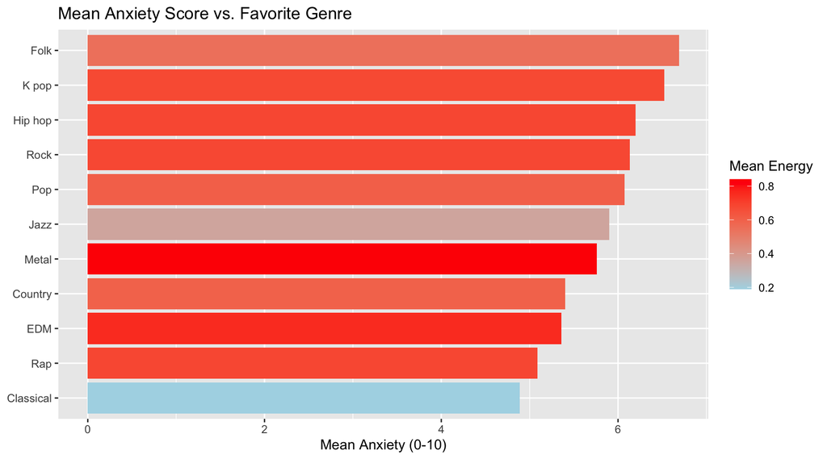

```r
genre_summary |>
  filter(n_respondents >= 10) |>
  mutate(Fav.genre = fct_reorder(Fav.genre, mean_anxiety)) |>
  ggplot(aes(x = Fav.genre, y = mean_anxiety, fill = mean_energy)) +
  geom_col() +
  coord_flip() +
  scale_fill_gradient(low = "lightblue", high = "red", name = "Mean Energy") +
  labs(
    title = "Mean Anxiety Score vs. Favorite Genre",
    x = NULL,
    y = "Mean Anxiety (0-10)"
  )
```

Classical has the lowest mean anxiety score and also the lowest energy, while Folk and K-pop have the highest anxiety scores despite having high energy. But Metal, which has the highest energy, does not have the highest anxiety score, sitting in the middle. This could mean there is some relationship between lower genre energy and lower anxiety, with Classical being the clearest example, but the pattern is not consistent across all genres, so no concrete conclusions can be made from this data.

# 5 Group Information

## 5.1 About Our Project

Our group is investigating how music listening habits and genre preferences relate to self-reported anxiety and stress levels, and whether the acoustic properties of genres (such as energy and valence) help explain these differences. We are enrolled in Section BE, and our TA is Runa He.

## 5.2 Team Members

### 5.2.1 Saket Marina

**Saket Marina** (Informatics, University of Washington; smarina1@uw.edu) is interested in how acoustic properties of music may provide insight into evidence-based therapeutic applications. He enjoys building data pipelines and visualizations and is interested in careers in business intelligence or machine learning.

### 5.2.2 Bella Schmidt

**Bella Schmidt** (Informatics, University of Washington; ischmi@uw.edu) is interested in understanding the intersection of mental health data and music consumption patterns. She is passionate about using data to uncover patterns in human behavior and is considering a career in UX research or data analytics.

### 5.2.3 Meher Madan

**Meher Madan** (Informatics, University of Washington; mmadan3@uw.edu) is interested in how data visualization can make mental health research more accessible. She is interested in pursuing a career in data science and hopes to apply analytical skills to real-world health and social issues.

## 5.3 Coding Notes

Tools used in this Deliverable:

- **Quarto multi-column layouts**: The `{.columns}` and `{.column width="X%"}` syntax for side-by-side content in Quarto was learned from the Quarto documentation at https://quarto.org/docs/presentations/revealjs/.
- **Custom CSS styling**: A separate `styles.css` file was used to customize code block and output appearance. We learned this approach from the Quarto documentation at https://quarto.org/docs/output-formats/html-basics.html#css-styles.